# Skupljanje podataka za EW-NBS

## 1. Ucitavanje podataka APR-a

Ucitacemo dva csv fajla, jedan sadrzi starije datume do 2013. godine dok drugi sadrzi novije datume od 2014. godine pa na dalje. Uvezivanje AOP-a po novom i starom kontnom okviru je vec uradjeno i sacuvano u data dva csv fajla. Sami fajlovi ne sadrze AOP-e!!! Razlog je što ne bi mogli da se spoje u jedan fajl budući da AOP-i po starom i novom kontnom okviru nisu mapirani jedana na jedan i samim tim ne bi mogli da se “nalepe” jedan na drugi u cilju dobijanja jednog `data.frame`-a jer bi imali razlicit broj AOP-a (citaj kolona), fajlovi medjutim sadrze proracunata finansijska racija. Fajlovi sadrze finansijska racija koja su sracunata iz premapiranih iz AOP-a dva kontna okvira (novi i stari kontni okvir). Za detaljniji pregled, uvid u pojedinacne AOP-e pogledati fajlove iz foldera ove analize, fajlovi ce se nalaziti u “~\Early warning\Bottom Up\Korak 3\Pokazatelji” gde ~ predstavlja adresu na kojoj je postavljen folder.  
Dodatno pojasnjenje o toliko spominjanim AOP-ima:

U APR bazi su sve pozicije iz bilansa stanja, bilansa uspeha, tokova gotovine, statistickih podataka o preduzecu (statisticki aneks) tretirane kao AOP pozicije, tako na primer broj zaposlenih datog preduzeca mozemo naci u polju AOP 605 za taj maticni broj, ili na primer vrednost stalne imovine iz bilansa stanja se nalazi u polju AOP 001. Medjutim usled menjanja kontnog okvira novi AOP-i sada imaju 4 umesto 3 cifre tako da gore navedane dve varijable se sada nalaze pod AOP-ima 9005 i 0002 respektivno. Medjutim nemoguce je premapirati sve AOP-e po starom nacinu izvestavanja sa AOP-ima po novom nacinu izvestavanja jedan na jedan pa je samim tim bilo i nemoguce prikazati tabela sa varijablama koje ucestvuju u proracunu finansijskih racija, vec su samo prikazani finansijski raciji kao krajnji rezultat.

```r
#generalne opcije i ucitavanje potrebnih biblioteka
if(require('readr')==F){install.packages('readr');require('readr')}
if(require("data.table",quietly = F) ==F){install.packages("data.table");require("data.table",quietly = F)}
if(require('DT')==F){install.packages('DT');require('DT')}
if(require('e1071')==F){install.packages('e1071');require('e1071')}
if(require('rpivotTable')==F){install.packages('rpivotTable');require('rpivotTable')}
if(require('cowplot')==F){install.packages('cowplot');require('cowplot')}
if(require('plotROC')==F){install.packages('plotROC');require('plotROC')}
if(require('pROC')==F){install.packages('pROC');require('pROC')}
if(require("InformationValue")==F){install.packages("InformationValue");require("InformationValue")}
if(require("Information")==F){install.packages("Information");require("Information")}
if(require("gtools")==F){install.packages("gtools");require("gtools")}
```

Ucitamo finansijska racija posle 2013. godine

```r
Pokazatelji_novi <-
  read_delim(
  "C:/Users/milos.cipovic/Desktop/Projekti/Early warning/Razvojni folder/Bottom Up/Korak 3/Pokazatelji/Pokazatelji novi.csv",
  ";",
  escape_double = FALSE,
  col_types = cols(Datum = col_date(format = "%m-%d-%Y")),
  locale = locale(encoding = "ASCII"),
  trim_ws = TRUE,
  progress = FALSE
  )
  gc()
```

Spajamo tabele `Pokazatelji_stari` i `Pokazatelji_novi` u jednu tabelu, ove dve tabele su ustvari predstavljale proracunata finansijska racija. Tabele su dobijene prethodnom analitikom i obradom podataka u excelu jer nije bilo moguce drugacije.. Pokrećemo `read_KA4_RK_data` funkciju za pripremanje KA4 i RK izvestaja. Kreiranje `NBS_data` funkcije je vec ranije opisano u scriptu ‘~\Early warning\Bottom Up\Korak 4\Early warning\nbs_data_prep.R’ koji sadrzi sustinski isti kod koji i funkcija `read_KA4_RK_data`.

```r
APR_data <- rbind.data.frame(Pokazatelji_stari, Pokazatelji_novi)
rm(Pokazatelji_stari , Pokazatelji_novi)
gc()


source("nbs_data_prep_function.R")
KA4_url = "C:/Users/milos.cipovic/Desktop/Baze podataka/K4 i APR i NPL/KA4_podaci.txt"
RK_url = "C:/Users/milos.cipovic/Desktop/Baze podataka/K4 i APR i NPL/RK_novi.txt"
NBS_data <- read_KA4_RK_data(KA4_url, RK_url)
```

Spajamo APR i NBS podatke i izbacujemo kolonu `NazivSektor` jer pravi probleme pri eksportu. Postoji sifrovana verzija ove kolone tako da smo u redu, prezivecemo bez nje. Tako da sada imamo pocetnu tabelu sa podacima koje poseduje NBS o duznicima koji se nalaze u bazi APR-a. Od podataka koje poseduje NBS najveci znacaj nam predstavlja indikator *difolta* koji nam govori da li ce posmatrani duznik sa sracunatim finansijskim racijima iz APR baze otici u *difolt* za dve godine ili ne.

```r
c = merge(
  NBS_data,
  APR_data,
  by.x = c("MAT_BR_DUZNIKA", "DATUM.x"),
  by.y = c("Jmb", "Datum")
  )
  #rm(APR_data,NBS_data)
  c = as.data.table(c)
  c[, NazivSektor := NULL]
```

Kao prvi korak u daljoj analizi potrebno je pre svega obratiti paznju na logicnost unesenih vrednosti kao i na nedostajuce vrednosti, tj. proracunati procenat nedostajucih vrednosti. Nelogicnosti je najlakse proveriti pregledom sumarnih statistika tako da ce nam sledeca tabela pomoci u tome.

## 2. Preliminarna analiza podataka

```r
#zamenjujem #DIV/0! i #N/A sa difoltnom vrednosti za nedostajuce vrednosti u R-u
b <- c
b <- as.data.frame(b)
for (i in 21:50) {
  temp <- b[, i]
  temp[temp == "#N/A" | temp == "#DIV/0!"] <- NA
  b[, i] <- temp
  b[, i] <- as.numeric(b[, i])
}

#sklanjam nepotrebne tabele da oslobodim memoriju jer mora se...kao i svuda do sada
rm(temp,i,KA4_url,RK_url,read_KA4_RK_data,APR_data)

#kreiram duplikat tabele na kom cu da daljeradim i zadrzavam samo bitne kolone,
#tj. neke ce mi biti potrebne kasnije ali za njih sam siguran da su ok jer sam ih kreirao i vec proverio
#u proceduri kreiranja podataka iz bankarskog sektora
b <- data.table(b)
clean_b <- b[, c(1, 4, 2, 9, 5, 7, 14, 16:50)]

#kreiram funkciju za proracun summary statistika
my.summary <- function(x, arg=T){
  x<-as.matrix(x)
  n<-nrow(x)
  data.frame(mean=mean(x, na.rm=arg),
    Trimmed_mean=mean(x,trim = 0.1,na.rm=arg),
    sd=sd(x, na.rm=arg),
    median=median(x, na.rm=arg),
    skewness=skewness(x,na.rm=arg),
    kurtosis=kurtosis(x,na.rm=arg),
    min=min(x, na.rm=arg),
    max=max(x,na.rm=arg),
    First_quartile=quantile(x,0.25,na.rm=arg),
    Third_quartile=quantile(x,0.75,na.rm=arg),
    n=length(x),
    NAspercent=round(sum(as.numeric(is.na(x))/n)*100,1)
    )
}

#kreiram sumarnu tabelu
summary_table1 <- sapply(clean_b[, 11:42], my.summary, arg = T)


#printujem je u notebook

tr_summary_table1 <- t(summary_table1)
formatRound(
  datatable(tr_summary_table1, caption = "Tabela 1.:Sumarni prikaz",
            filter = 'none'),
  columns = colnames(tr_summary_table1)
)
```

### 2.1 Nelogicni unosi

U ovom koraku je potrebno pre svega pregledati kategoricke varijable za nelogicne unose, naime, primeceno je da varijabla koja bi trebalo da oznacava velicinu duznika i uzima vrednosti od 1 do 4 sadrzi vrednosti koje su znacajno vece[^1], takodje, malo je verovatno da je prosecan broj zaposlenih iznosi 7613. Uvidom u podatke doslo se do zakljucka da su date nelogicnosti rezultat razlike u strukturi izvestaja finansijskih institucija i ostalih lica koja su duzna da podatke unose u APR bazu, tako da AOP 602 kod finansijskih institucija ne predstavlja sifru velicine, isto vazi i za polje koje oznacava sifru broja zaposlenih. Daljim uvidom dolazi se do jos nekih saznanja u konzistentnosti AOP-a 602 koji oznacava velicinu lica, naime, otkriveno je jos jedno polje u bazi koju NBS poseduje, a koje nosi informacije o velicini lica, ovo polje nema sifru AOP-a. Posle provere podataka koje posedujemo i njihovim uporedjivanjem sa vrednostima sa APR sajta opredelili smo se za AOP 602. Prethodno opisana dva polja su se u pojedinim slucajevima razlikovala, zbog toga je i izvrsena analiza. Naime, pomenuto polje koje se nalazi u pivot tabelama (nacin na koji NBS ima pristup APR bazi) je u odredjenom broju slucajeva prikazivalo podatke od prethodne godine. Ovo je slucaj samo sa starim nacinom izvestavanja, dakle do 2013. godine!  
Nastavljamo sa analizom tako sto cemo izbaciti iz tabele observacije sa vrednostima u koloni `Velicina` vecim od 4 i manjim od 1 i ponovo pregledati strukturu sumarne tabele. Naknadno, izbacicemo sva lica koja ne pripadaju grupi “Privrednih drustava i zadruga” obzirom da narusavaju homogenost uzorka kao i da im AOP pozicije nisu mapirane kao Privrednim drustavima i zadrugama pa su samim tim te observacije i glavni uzrok nekonzistentnosti u podacima.

```r
#ucitavam unapred pripremljenu tabelu koja nam za posmatrani mb i godinu daje njegovu pripadnost odredjenom sektoru, tj. govori nam iz kojeg je finansijskog izvestaja data observacija u APR-u
gc()

Pravna_forma <-
  read_delim(
  "C:/Users/milos.cipovic/Desktop/Projekti/Early warning/Razvojni folder/Bottom Up/Korak 5/Pravna forma.csv",
  "|",
  escape_double = FALSE,
  trim_ws = TRUE,
  col_types = cols(Datum = col_date(format = "%Y")),
  progress = FALSE
  )

#merdzujem poidatke sa clean_b, tj. preciscavam clean_b tako sto posto merdzujem zadrzim samo one sa
#sa sifrom 14000 sto predstavlja "Privredna drustava i zadruge"
clean_b <-
  merge(
  clean_b,
  Pravna_forma,
  by.x = c("DATUM.x", "MAT_BR_DUZNIKA"),
  by.y = c("Datum1", "Jmb")
  )

clean_b_ <- clean_b

clean_b <-
  clean_b[Sifra == 1400][, c("Naziv", "Sifra", "NazivPravnogLica") := NULL]
  #izbacim vrednosti velicina koje su vece od 4, double check inace ne bi smelo da smanji broj redova
clean_b <- clean_b[Velicina <= 4 & Velicina > 0]
#ponovo kreiram data.frame summary_table
summary_table <- sapply(clean_b[, 11:42], my.summary, arg = T)
#transponujem
tr_summary_table <- t(summary_table)
#printujem tabelu

formatRound(
            datatable(
                      tr_summary_table,
                      caption = "Tabela 2.:Sumarni prikaz bez banaka i ostalih finansijskih institucija",
                      filter = 'none',
                      extensions = 'Buttons',
                      options = list(
                                     pageLength=13,
                                     dom = 'Bfrtip',
                                     buttons = c(
                                                  'copy',
                                                  'csv',
                                                  'excel'
                                                  )
                                     )
                      ),
            columns = colnames(tr_summary_table)
           )
```

### 2.2 Nedostajuce vrednosti

Tretiranje nedostajucih vrednosti kao korak u razvoju modela nosi dodatnu tezinu imajuci u vidu da ce biti potrebno tretirati nedostajuce vrednosti i u procesu samog predvidjanja solventnosti banke (a to je krajnji cilj ove analize) posto je model evaluiran. Samim tim, uvidom u literaturu o najboljim praksama tretmana nedostajucih observacija odlucujemo se za sledeci postupak koji je predlozen u knjizi *Developing, Validating and Using Internal Ratings*:

- Red observacije se brise ukoliko nedostaje vise od 75% podataka u njemu
- Kolona varijable se brise ukoliko imaju vise od 10% nedostajucih vrednosti[^2]
- Ukoliko nedostaje manje od 10% observacije posmatrane varijable vrsi se imputacija (zamena) observacija medijanima varijabli. Na ovaj nacin se izbegava osetljivost na autlajere koju poseduje srednja vrednost. Pri cemu se medijana posebno proracunava za zdrave a posebno za duznike u statusu neizmirenja obaveza. Ovo, medjutim nije slucaj kod validacionog uzorka, kao takav on ne bi trebao da sadrzi nikakvu informaciju o tome da li ce posmatrani duznik u buducnosti prestati da izmiruje svoje obaveze, samim tim u validacionom uzorku kao vrednost inputacije koristimo medijanu komplet varijable, nezavisno od toga da li pripada solventnim ili nesolventnim duznicima.
- Indikatori se transformisu u kategoricke varijable ukoliko postoji apriori znanje o njihovom znacaju i ukoliko ne postoje proksi indikatori koji bi zamenili posmatrani indikator.

Varijable koje predstavljaju problem u smislu procenata nedostajanja su:

- *Racio_novcane_likvidnosti_(Cash_ratio)* - ova varijabla je na granici po gorenavedenim kriterijumima
- Racio_obrta_potrazivanja_od_kupaca
- Racio_obrta_poslovne_imovine
- Rast_EBITDA
- *Stopa_prinosa_na_ukupna_sredstva_pre_oporezivanja* - ova varijabla je na granici po gorenavedenim kriterijumima
- Rast_prihoda_od_prodaje
- Pokrice_neto_kamata

Zapazamo da se brisanje nedostajucih observacija preporucuje tek posto su ispunjeni odredjeni uslovi bez obzira na velicinu uzorka, brisanje nedostajucih observacija bi generalno trebalo da bude poslednja opcija pri ciscenju podataka.  
Jos jedna cinjenica ce imati udeo u izboru varijabli. Pre svega cetiri pokazatelja u listi su dinamicki i prikazuju stopu rasta odredjene velicine, cime se gubi jedna (prva) godina observacija, samim tim ova cetiri pokazatelja ce u prvoj godini imati sve nedostajuce vrednosti. Navodimo ove racije:

- Racio obrta potraživanja od kupaca;
- Racio obrta poslovne imovine;
- Rast EBITDA;
- Rast prihoda od prodaje.

Odluka o brisanju ili zadrzavanju ovih varijabli ce prevashodno zavisiti od njihove diskriminativne moci pa zatim od gore navedenih kriterijuma. Dodatno pojasnjavamo da bi zadrzavanje ovih varijabli skratilo citav uzorak za prvu godinu observacija, pa ce i velicina uzorka biti presudan faktor.

Pre primene gore navedenih postupaka vazno je navesti da cemo mi raditi tri modela, u zavisnosti od velicine duznika. Sama podela ce biti izvrsena na osnovu varijable `Velicina` koja razvrstava lica prema unapred utvrdjenim kriterijumima APR-a videti [APR/“Критеријуми за разврставање и граничне вредности за 2016. годину”](http://www.apr.gov.rs/Регистри/Финансијскиизвештаји/Разврставањеправнихлица/Критеријумизаразврставањеиграничневредности.aspx). U cilju uzimanja u obzir velicine izlozenosti koristicemo i varijablu koja predsavlja udeo izlozenosti posmatranog duznika u kapitalu banke koja je prema njemu izlozena. Ova varijabla ce biti naknadno sracunata i ima za cilj da uzme u obzir razlicit tretman prema duzniku prema njegovoj velicini posmatrano sa stanovnistva banke. Buduci da su odredjeni duznici zaduzeni kod vise banaka posmatrace se samo one banke u kojima je dati duznik najvise zaduzen. Ovo je ujedno i rezultat ranije obrade podataka iz KA4 i RK obrasca (videti skript “~Early warning\nbs_data_prep.R”) gde su o ovim slucajevima visestruke izlozenosti sacuvane observacija kod banaka prema kojima poseduju najveca dugovanja. Pre pocetka *univariate* analize potrebno je proracunati vec spomenuti udeo izlozenosti posmatranog duznika u regulatornom kapitalu banke. To cemo uraditi tako sto cemo inportovati vec pripremljenu tabelu sa serijom vrednosti regulatornog kapitala banaka.

```r
#ucitavam seriju re4gulatornog kapitala za banke
regulatory_capital <- read_delim(
  "C:/Users/milos.cipovic/Desktop/Projekti/Early warning/Razvojni folder/Bottom Up/Korak 5/regulatory_capital.csv",
  ";",
  escape_double = FALSE,
  col_types = cols(Datum = col_date(format = "%d.%m.%Y")),
  trim_ws = TRUE
)

#prilepljujem je za clean_b tabelu
clean_b <-
  merge(
  clean_b,
  regulatory_capital,
  by.x = c("DATUM.x", "MATICNI_BROJ.x"),
  by.y = c("Datum", "MB")
  )

#proracunavam udeo izlozenosti i odstranjujem kolone viska koje su dosle sa tabelom regulatory_capital
clean_b <-
  clean_b[, udeo_u_kapitalu := (IZLOZENOST.x / Brojilac) * 1000]#skalirano zbog numerike
  clean_b <- clean_b[, c("Brojilac", "Imenilac", "Pokazatelj") := NULL]

#cistim smece
  rm(
    b,
    Pravna_forma,
    regulatory_capital,
    summary_table,
    summary_table1,
    tr_summary_table
    )
    gc()
```

Na kraju pogledajmo tabelu ciscenja podataka:

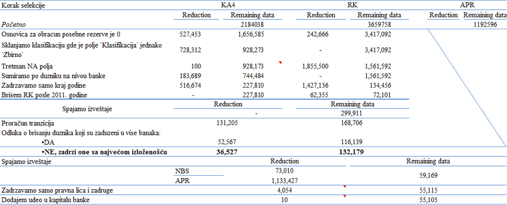

Tabela 3.: Pregled obrade podataka od pocetnih pa do podataka koji ulaze

## 3. *“Univariate”* analiza

Do sada nismo jos uvek razmatrali kontinualne varijable, razlog je bio sto uzorak jos uvek nije bio podeljen na tri poduzorka u zavisnosti od velicine duznika. Pre pocetka *univariate* analize razdvojicemo uzorak na tri dela. Posebno ce se evaluirati modeli za mikro i mala, srednja i velika preduzeca. Takodje, tretman nedostajucih vrednosti je samo deskriptivno naveden u smislu metodoloskog pravca u kom ce se ici pri obradi. Sve ove analize i one koje slede ce se obaviti pojedinacno za svaku grupu duznika ponaosob. Pre nego sto se uzorak razdvoji, u ovoj sekciji, ukratko ce biti opisati raciji koji su korisceni, njihova ekonomska logika i ocekivanu vezu sa verovatnocom *difolta*, jer ce se isti set racija koristiti u sva tri slucaja. Po opisu racija, u nastavku ove sekcije, ce se ispitati broj nedostajucih vrednosti i njihov tretman, prisutnost autlajera i njihov tretman, radna hipoteza, monotonost, moc diskriminacije i korelacija za svaki od tri modela. Svi prethodno navedeni postupci imaju za cilj sto bolju pred selekciju varijabli pred ulzak u zavrsnu fazu *multivariate* analizu gde ce *stepwise* procedurom biti izabrani konacni modeli

### 3.1 Finansijski raciji, ekonomska logika i radna hipoteza

Kao polazna osnova poslo se od pet grupa pokazatelja koji bi, idealno, trebalo da nam daju informaciju o:

- Likvidnosti
- Solventnosti
- Profitabilnosti
- Poslovne aktivnosti
- Ostali pokazatelji koje je tesko svrstati

Pokazatelji, njihova pripadnost grupi i hipoteza ekonomske logicnosti njihove relacije sa verovatnocom nastupanja neizmirenja obaveza je prikazana u sledecoj tabeli:

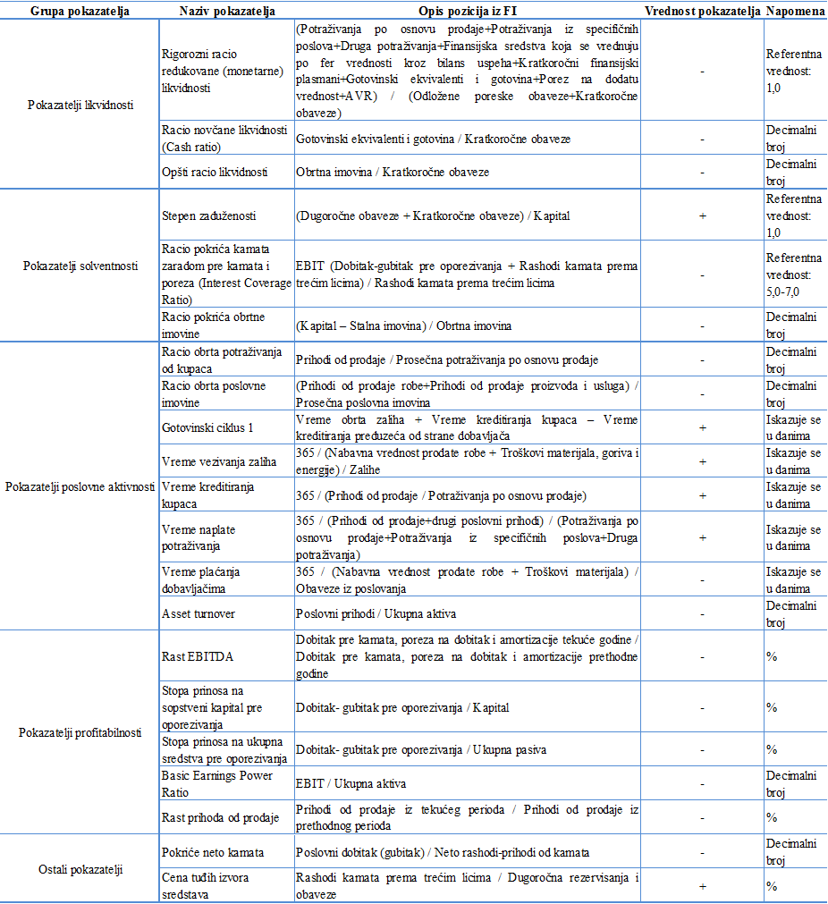

Tabela 4.: Polazni raciji koji ulaze u univariate analizu

### 3.2 *“Univariate”* analiza

Razdvajamo uzorak na tri podgrupe:

```r
#kreiram tri nove tabele sa kojima dalje radim
small <- clean_b[Velicina <= 2, ]
medium <- clean_b[Velicina == 3, ]
large <- clean_b[Velicina == 4, ]
#brisem preostale medjukorake
rm(c, NBS_data)
gc()
```

Prvo ćemo detaljno analizirati **velika preduzeca** (podaci `large`) počevši od svih gore navedenih koraka u analizi, tako da će ovaj deo imati tri podgrupe, zavisno od same veličine dužnika. Samim tim i krećemo u detaljnu analizu sada…

### Univariate analiza velikih preduzeća

Potrebno je pre svega razdvojiti uzorak na validacioni i estimacioni. U nacelu pravilo je da se uzorak deli na 70:30 na stranu estimacije, medjutim ukoliko kuburimo sa podacima Lemeshow u svom [kursu o logistickoj regresiji](https://www.canvas.net/browse/osu/courses/applied-logistic-regression) argumentuje da je mnogo bitnije da imamo kompletniji uzorak za estimaciju, tako da cemo se voditi ovom logikom i u nasem slucaju.  
Pa, pocnimo.

```r
#izracunam broj redova
broj.red.lrge<-nrow(large)
broj.difolta.lrge<-sum(as.numeric(large$default.y==1))
procenat.difolta<-broj.difolta.lrge/broj.red.lrge
```

Dakle u najboljem slucaju, ne racunajuci missing value imamo 155 difolta, sto nam deluje kao dovoljno, ukoliko bismo zadrzali 30% bili bismo na granici. Medjutim da bismo se osigurali zadrzacemo 75%, time opet imamo dovoljno difolta za validaciju (oko 40), ovde sam se vodio savetom profesora Lemeshow-a koji kaze da se u ovoj situaciji uvek pokusa zadovoljiti *training sample*. S druge strane racio nesolventnih u ukupnim duznicima moze imati razlicite vrednosti, tj. ne postoji konsenzus u literaturi o ovoj vrednosti. Ovde biramo da zadrzimo trenutan racio u uzorku tako da cemo uzeti 75% od (solventnih i nesolventnih) duznika zajedno i raditi estimaciju na njemu. Ovim postupkom smo izbegli postupak kalibracije jer smo u *training* uzorku zadrzali stvarnu frekvenciju defaulta, citaj, verovatnocu defoulta. Jedan problem koji se moze potencijalno javiti je validnost Hosmer–Lemeshow testa sa 40 difolta.

```r
set.seed(42)
#zbog reprodukcije
sample.lrg <-
sample(broj.red.lrge, size = round(0.75 * broj.red.lrge, 0))
lrge.training <- large[sample.lrg, ]
lrge.test <- large[-sample.lrg, ]
```

#### **Testiranje radne hipoteze, diskriminativnosti, korelacione matrice**

Jos jednom cemo pregledati varijable:

```r
#rpivotTable(lrge.training)
summary_table<-t(sapply(lrge.training[,11:43],my.summary,arg=T))
tr_summary_table<-t(summary_table)
formatRound(
            datatable(
                      summary_table,caption = "Tabela 3.:Sumarni prikaz",
                      filter = 'none'
                      ),
            columns = colnames(summary_table)
           )
```

Kod kategorickih varijabli posmatracemo tabele frekvencija tamo gde to bude imalo smisla i sprovesti Chi-squared test. Ovom prilikom potrebno je i pregrupisati ove varijable tako da budu zadovoljeni kriterijumi:

- broj *difolta* po kategoriji kategoricke varijable mora biti minimum 5
- ukupan broj duznika po kategoriji kategoricke varijable mora biti veci od sto
- pravilo 1 u 10, za svakih 10 difolta možemo dodati jednu objašnjavajuću, ovo pravilo nam sluzi samo kao vodilja
- *default rate* mora biti statisticki razlicit od *default rate*-a ukupnog uzorka, inace se vrsi pregrupacija
- iako cemo ispitati hipotezu sagledavanjem tabela frekvencija, poslednju rec ce nam dati sami model i njegove *p* vrednosti, odnosno *likelihood ratio* test

Prvo pregledajmo samu distribuciju jos jednom, mada su neke stvari vec jasne iz Tabele 3 hajde ipak da pogledamo.  
Prvo kreiramo funkciju za plotiranje: qq plota, box plota, poredjenja gustina verovatnoce (kernela empiriskih distribucija verovatnoce) i konacno za proveru diskriminacije ROC krive.

```r
#delimo uzorak na kontinualne i kategoricke
lrge.training.continualne<-lrge.training[,c(7,6,11,13:43)]
lrge.training.kategoricke<-lrge.training[,c(7,8,9,10,12)]

#delimo uzorak prema difoltu
lrge.training.difolt<-lrge.training[default.y==1]
lrge.training.difolt.continualne<-lrge.training.difolt[,c(7,6,11,13:43)]
lrge.training.difolt.kategoricke<-lrge.training.difolt[,c(8,9,10,12)]

lrge.training.zdravi<-lrge.training[default.y==0]
lrge.training.zdravi.continualne<-lrge.training.zdravi[,c(7,6,11,13:43)]
lrge.training.zdravi.kategoricke<-lrge.training.zdravi[,c(7,8,9,10,12)]

ploting<-function(dataframe, predictor_col, default_column_col){

  #transformacija podataka
  dataframe=as.data.frame(dataframe)
  data<-data.frame(predictor=dataframe[,predictor_col],
                   default_column=factor(dataframe[,default_column_col]))
  data<-na.omit(data)

#density plot#####################
  density<-ggplot(data, aes(predictor, fill=factor( default_column))) +
  geom_density(alpha=.5) +
  scale_fill_manual(values = c('#999999','#E69F00')) +
  theme(legend.position = "none")+xlim(quantile(data$predictor,c(0.05,0.95),na.rm = T))

#boxplot############################
box_plot<-ggplot(data, aes(y=predictor, x= default_column, fill=default_column))+
  geom_boxplot(alpha=0.5)
  # compute lower and upper whiskers
ylim1 = boxplot.stats(data$predictor)$stats[c(1, 5)]
  # scale y limits based on ylim1
box_plot = box_plot + coord_cartesian(ylim = ylim1*3)+
  scale_fill_manual(values = c('#999999','#E69F00'))

#roc curve plot#######################
ROC_plot <-
  ggplot(data, aes(m = predictor, d = as.numeric(default_column))) + geom_roc() +
  geom_abline(intercept = 0,
              slope = 1,
              color = 'red')

result <- auc(data$default_column, data$predictor)

a = paste("Area under the curve:",
          round(ci(result)[[1]], 3),
          ", ",
          round(result, 3),
          ", ",
          round(ci(result)[[3]], 3))

ROC_plot <- ROC_plot + labs(title = a)

#QQ plot

qs = seq(0.001, 0.999, by=0.001)
df.qs = data.frame(quantile.P = qs,
                   q.val.Normal = qnorm(qs,mean(data$predictor),sd(data$predictor)),
                   q.val.X = quantile(data$predictor,qs))
QQ_plot=ggplot(df.qs, aes(q.val.Normal, q.val.X))+
  geom_point(col='#999999', cex=2)+
  geom_line(col='#999999', size=0.75)+
  geom_abline(position="identity")

plot_grid(density,box_plot,ROC_plot,QQ_plot,ncol = 2)

}
```

#### Krećemo sa opisom svake varijable ponaosob:

## Neprekidne promenljive:

#### Udeo ispravke u ukupnim kreditima

```
Ignoring unknown parameters: positionRemoved 63 rows containing non-finite values (stat_density).D not labeled 0/1, assuming 1 = 0 and 2 = 1!
```

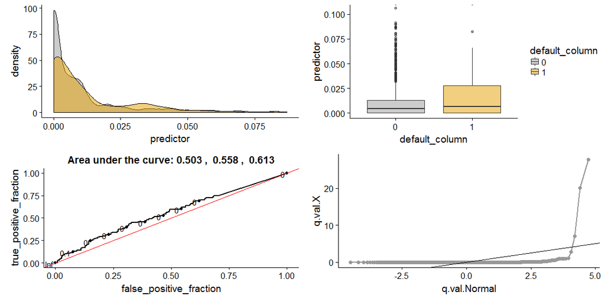

```r
#definisem funkciju za plotovanje
ploting(lrge.training,6,7)
```

Vidimo da distribucije odstupaju daleko od normalne, dalje preklapanje distribucija solventnih u nesolventnih duznika je razocaravajuce, postoji 7 autlajera koji imaju nelogicne vrednosti koji vuku poreklo iz rk obrasca. Iako box plot pokazuje odredjeni stepen diskriminacije u smislu da su solventni duznici manje ispravljeni od nesolventnih, generalno ROC kriva pokazuje da je diskriminacija marginalna iako je znacajna na nivou poverenaj od 95%, ipak, znacajnost je marginalna. Autlajeri ima ih, ima ih mnogo. Buduci da ce slicno biti i sa ostalim varijablama kreiramo taksativan opis u vidu buleta za svaku varijablu kao sto sledi za ovu:

- Radna hipoteza-nismo postavili radnu hipotezu za ovu varijablu
- Diskriminativnost - postoji na 95% sigurnosti
- autlajeri - naravno ima ih ima
- normalnost - ma da…

#### Broj zaposlenih

```
Ignoring unknown parameters: positionRemoved 126 rows containing non-finite values (stat_density).D not labeled 0/1, assuming 1 = 0 and 2 = 1!
```

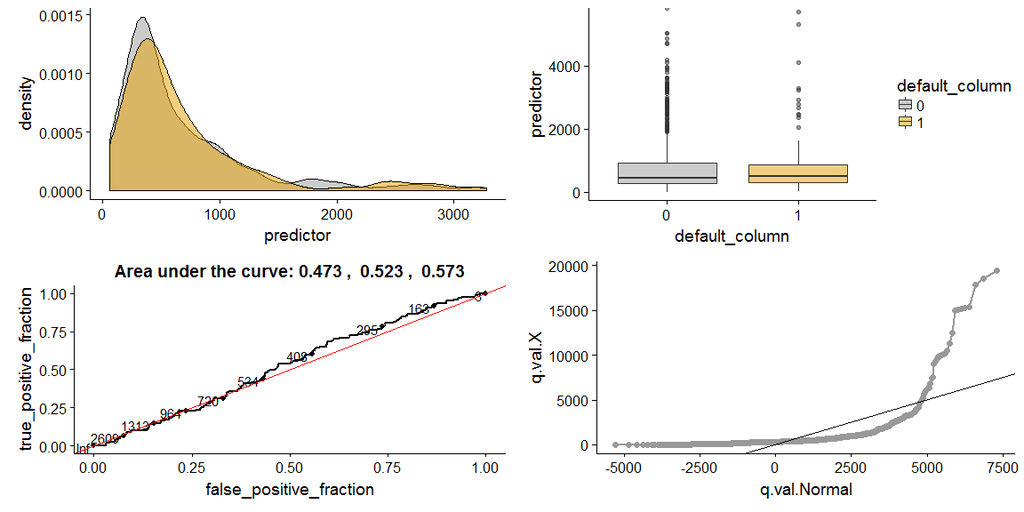

```r
#definisem funkciju za plotovanje
ploting(lrge.training,11,7)
```

- Radna hipoteza-nismo postavili radnu hipotezu za ovu varijablu
- Diskriminativnost - nema je
- autlajeri - naravno ima ih
- normalnost - ma da…

#### Rigorozni racio redukovane (monetarne) likvidnosti

```
Ignoring unknown parameters: positionRemoved 122 rows containing non-finite values (stat_density).D not labeled 0/1, assuming 1 = 0 and 2 = 1!
```

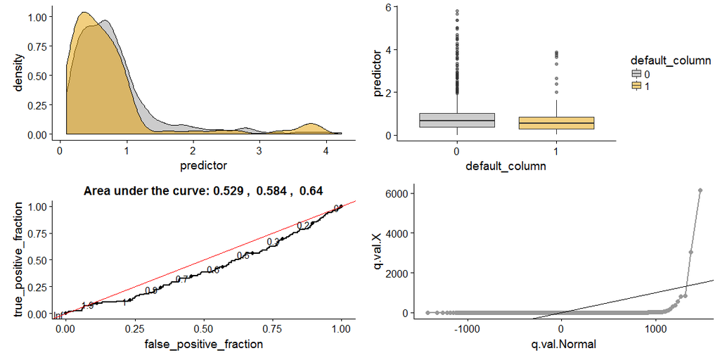

```r
#definisem funkciju za plotovanje
ploting(lrge.training,13,7)
```

- Radna hipoteza-zadovoljena, veci difolt kod manjih vrednosti
- Diskriminativnost - ima na 95% znacajnosti
- autlajeri - naravno ima ih
- normalnost - ma da…

#### Racio novcane likvidnosti (Cash_ratio)

```
Ignoring unknown parameters: positionRemoved 114 rows containing non-finite values (stat_density).D not labeled 0/1, assuming 1 = 0 and 2 = 1!
```

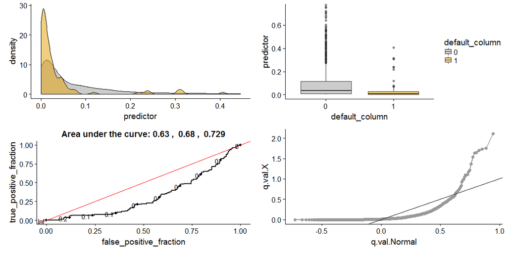

```r
#definisem funkciju za plotovanje
ploting(lrge.training,14,7)
```

- Radna hipoteza-zadovoljena, veci difolt kod manjih vrednosti
- Diskriminativnost - ima na 95% znacajnosti i obecava!!!
- autlajeri - naravno ima ih
- normalnost - ma da…

#### Opsti racio likvidnosti

```
Ignoring unknown parameters: positionRemoved 126 rows containing non-finite values (stat_density).D not labeled 0/1, assuming 1 = 0 and 2 = 1!
```

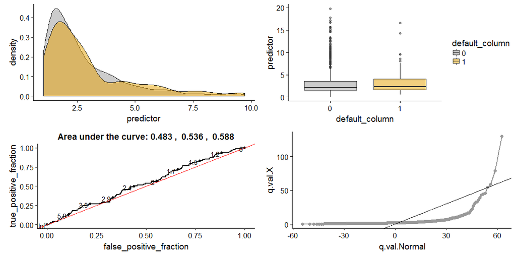

```r
#definisem funkciju za plotovanje
ploting(lrge.training,15,7)
```

- Radna hipoteza-nezadovoljena, veci difolt kod vecih vrednosti
- Diskriminativnost - nema na 95% znacajnosti i to ti je!!!
- autlajeri - naravno ima ih
- normalnost - ma da…

#### Stepen_zaduzenosti

```
Ignoring unknown parameters: positionRemoved 120 rows containing non-finite values (stat_density).D not labeled 0/1, assuming 1 = 0 and 2 = 1!
```

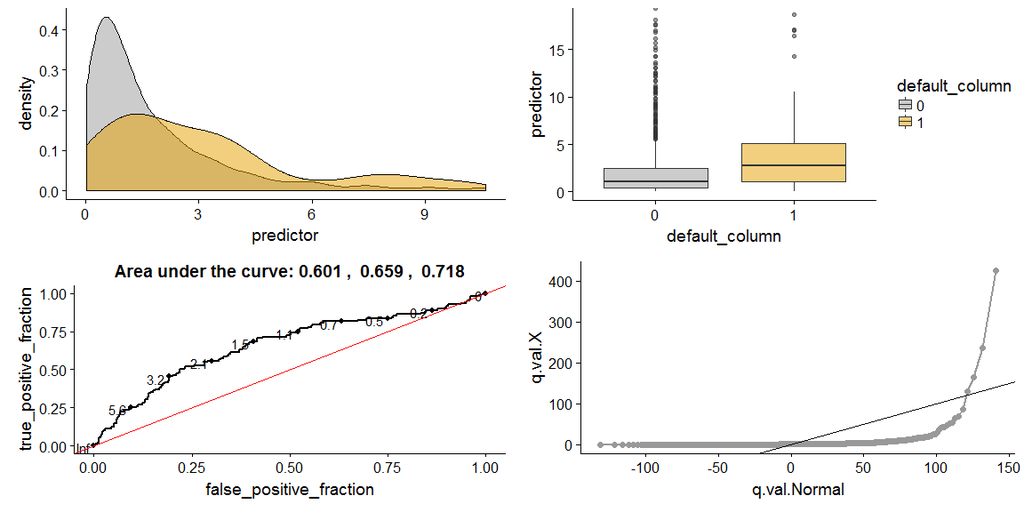

```r
#definisem funkciju za plotovanje
ploting(lrge.training,16,7)
```

- Radna hipoteza-zadovoljena, veci difolt kod vecih vrednosti
- Diskriminativnost - ima na 95% znacajnosti!!!
- autlajeri - naravno ima ih
- normalnost - ma da…

#### Interest Coverage Ratio

```
Ignoring unknown parameters: positionRemoved 126 rows containing non-finite values (stat_density).D not labeled 0/1, assuming 1 = 0 and 2 = 1!
```

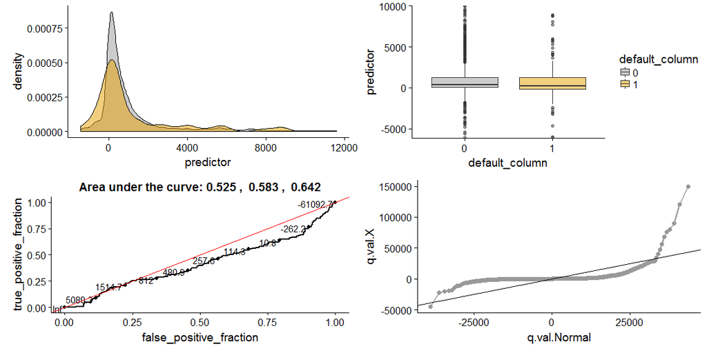

```r
#definisem funkciju za plotovanje
ploting(lrge.training,17,7)
```

- Radna hipoteza-zadovoljena, veci difolt kod manjih vrednosti
- Diskriminativnost - ima na 95% znacajnosti i ok je, moze da prodje, mada krivuda sto nije dobro!!!
- autlajeri - naravno ima ih
- normalnost - ma da, ali bar lici na nesto normalno…

#### Racio pokrica obrtne imovine

```
Ignoring unknown parameters: positionRemoved 126 rows containing non-finite values (stat_density).D not labeled 0/1, assuming 1 = 0 and 2 = 1!
```

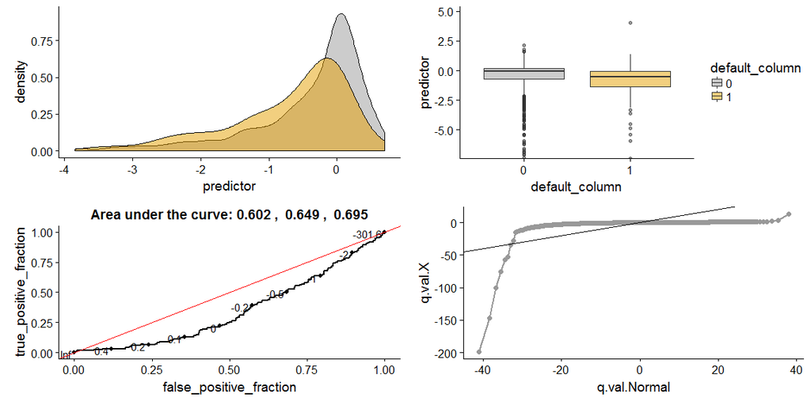

```r
#definisem funkciju za plotovanje
ploting(lrge.training,18,7)
```

- Radna hipoteza-zadovoljena, veci difolt kod manjih vrednosti
- Diskriminativnost - ima na 95% znacajnosti i ok je, solidno!!!
- autlajeri - naravno ima ih
- normalnost - ma da

#### Racio obrta potrazivanja od kupaca

```
Ignoring unknown parameters: positionRemoved 112 rows containing non-finite values (stat_density).D not labeled 0/1, assuming 1 = 0 and 2 = 1!
```

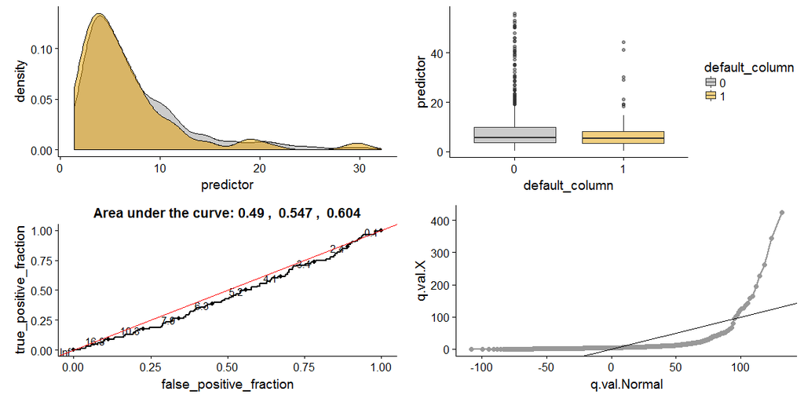

```r
#definisem funkciju za plotovanje
ploting(lrge.training,19,7)
```

- Radna hipoteza-zadovoljena, veci difolt kod manjih vrednosti
- Diskriminativnost - nema je 95% znacajnosti
- autlajeri - naravno ima ih
- normalnost - ma da, vise kao $\tilde\chi^2$nost hihihi, kapiras hi kao hi distribucija :) …

#### Racio obrta poslovne imovine

```
Ignoring unknown parameters: positionRemoved 112 rows containing non-finite values (stat_density).D not labeled 0/1, assuming 1 = 0 and 2 = 1!
```

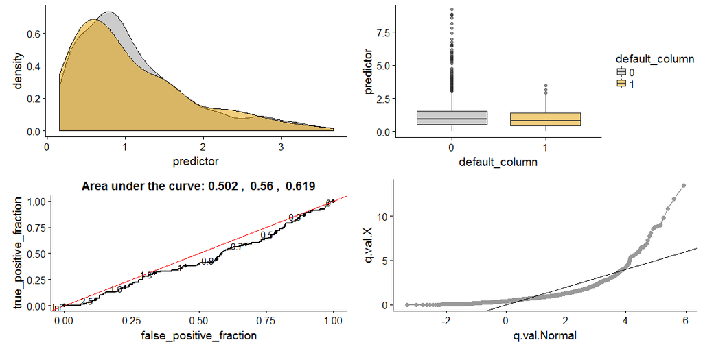

```r
#definisem funkciju za plotovanje
ploting(lrge.training,20,7)
```

- Radna hipoteza-zadovoljena, veci difolt kod manjih vrednosti
- Diskriminativnost - ima na 95% znacajnosti i ok je, moze da prodje, mada krivuda sto nije dobro!!!
- autlajeri - naravno ima ih
- normalnost - ma da…

#### Gotovinski ciklus 1

```
Ignoring unknown parameters: positionRemoved 126 rows containing non-finite values (stat_density).D not labeled 0/1, assuming 1 = 0 and 2 = 1!
```

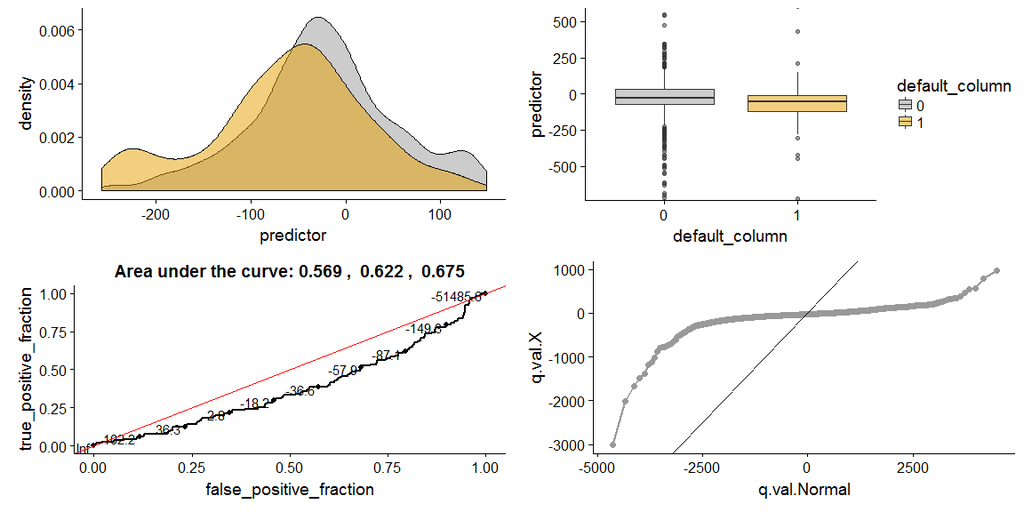

```r
#definisem funkciju za plotovanje
ploting(lrge.training,21,7)
```

- Radna hipoteza-nezadovoljena, veci difolt kod manjih vrednosti, zasto pitam se
- Diskriminativnost - ima na 95% znacajnosti i ok je, moze da prodje, mada krivuda sto nije dobro!!!
- autlajeri - naravno ima ih
- normalnost - ma da…

#### Vreme vezivanja zaliha

```
Ignoring unknown parameters: positionRemoved 126 rows containing non-finite values (stat_density).D not labeled 0/1, assuming 1 = 0 and 2 = 1!
```

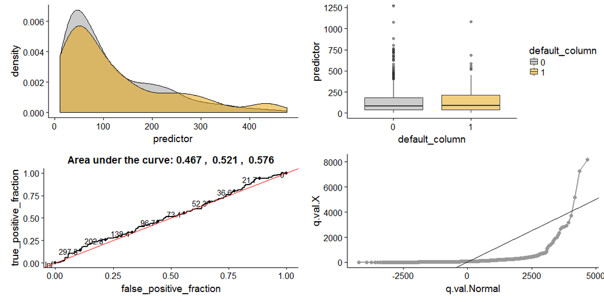

```r
#definisem funkciju za plotovanje
ploting(lrge.training,22,7)
```

#### Vreme kreditiranja kupaca

```
Ignoring unknown parameters: positionRemoved 126 rows containing non-finite values (stat_density).D not labeled 0/1, assuming 1 = 0 and 2 = 1!
```

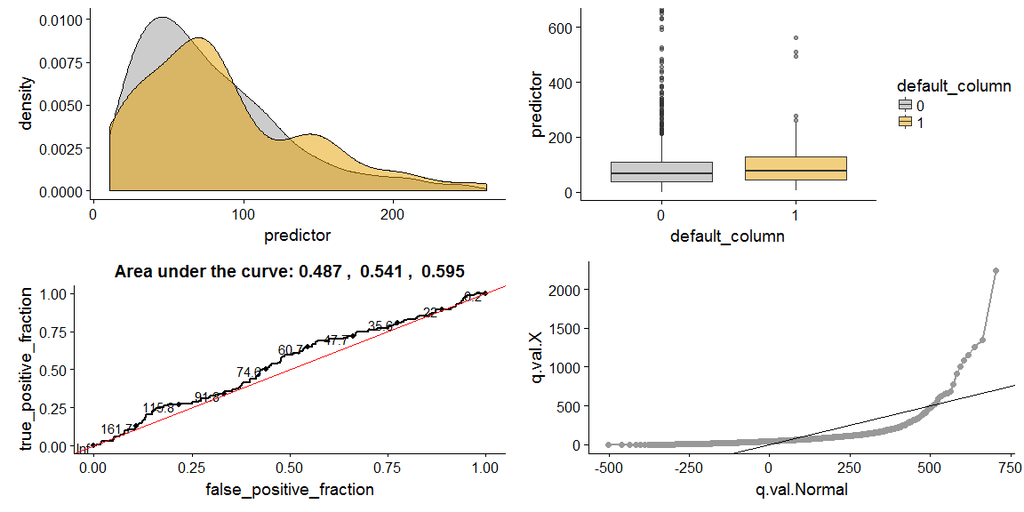

```r
#definisem funkciju za plotovanje
ploting(lrge.training,23,7)
```

#### Vreme naplate potraživanja

```
Ignoring unknown parameters: positionRemoved 126 rows containing non-finite values (stat_density).D not labeled 0/1, assuming 1 = 0 and 2 = 1!
```

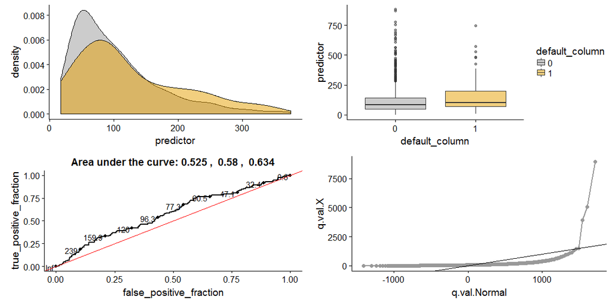

```r
#definisem funkciju za plotovanje
ploting(lrge.training,24,7)
```

#### Vreme plaćanja dobavljačima

```
Ignoring unknown parameters: positionRemoved 126 rows containing non-finite values (stat_density).D not labeled 0/1, assuming 1 = 0 and 2 = 1!
```

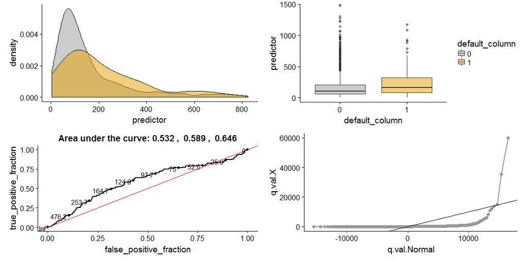

```r
#definisem funkciju za plotovanje
ploting(lrge.training,25,7)
```

#### Asset turnover

```
Ignoring unknown parameters: positionRemoved 126 rows containing non-finite values (stat_density).D not labeled 0/1, assuming 1 = 0 and 2 = 1!
```

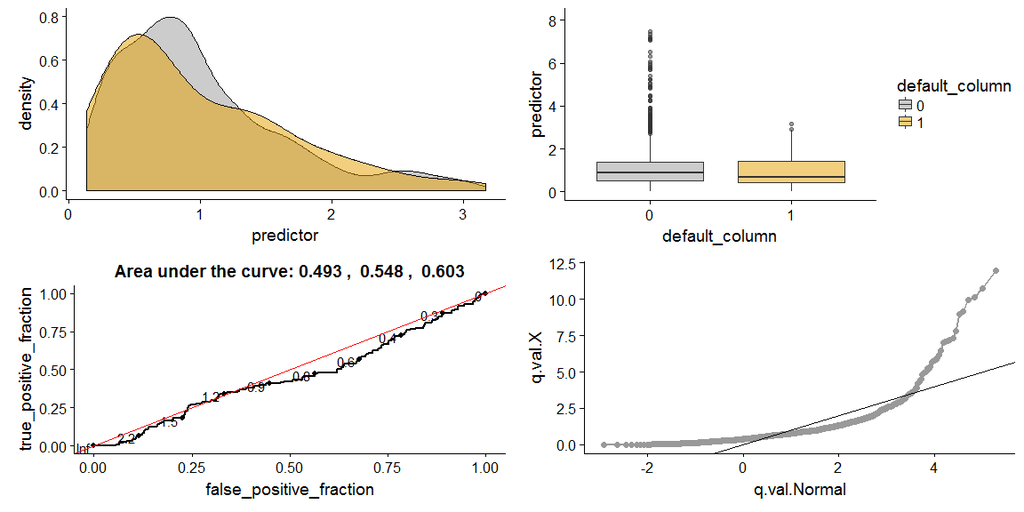

```r
#definisem funkciju za plotovanje
ploting(lrge.training,26,7)
```

- Radna hipoteza-zadovoljena, veca verovatnoca difolta kod manje medijane
- Diskriminativnost - nema na 95% znacajnosti, ipak cemo je uzeti, zbog diskriminativnosti u manjim vrednostima
- autlajeri - naravno ima ih
- normalnost - ma da…

#### Rast EBITDA

```
Ignoring unknown parameters: positionRemoved 112 rows containing non-finite values (stat_density).D not labeled 0/1, assuming 1 = 0 and 2 = 1!
```

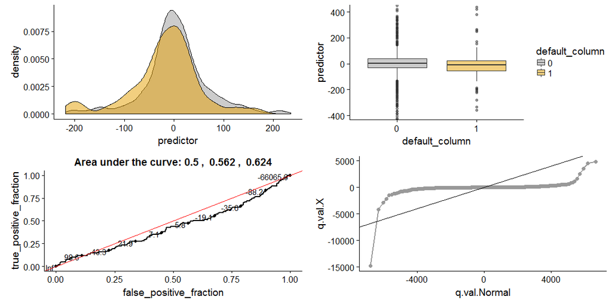

```r
#definisem funkciju za plotovanje
ploting(lrge.training,27,7)
```

- Radna hipoteza-zadovoljena, veca verovatnoca difolta kod manje medijane
- Diskriminativnost - na granici na 95% znacajnosti, uzecemo, mada menja diskriminativnost, videcemo posle multivariata
- autlajeri - naravno ima ih
- normalnost - ma da…

#### Stopa prinosa na sopstveni kapital pre oporezivanja

```
Ignoring unknown parameters: positionRemoved 120 rows containing non-finite values (stat_density).D not labeled 0/1, assuming 1 = 0 and 2 = 1!
```

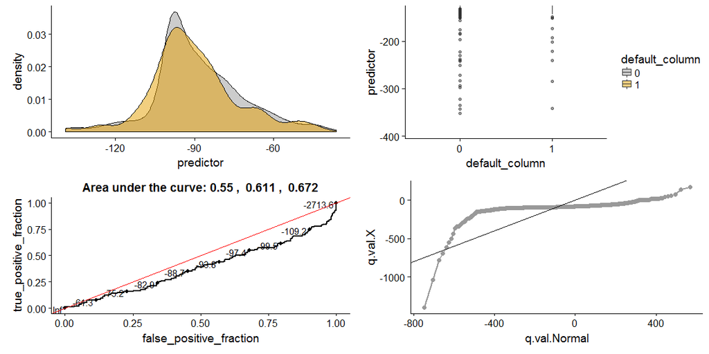

```r
#definisem funkciju za plotovanje
ploting(lrge.training,28,7)
```

- Radna hipoteza-ne znam koji mu je djavo ali evo ovde cemo medijana zdravog je -90.5002495 a nesolventnog je -96.5217785 sto odgovara radnoj hipotezi
- Diskriminativnost - znacajno na 95% znacajnosti, uzecemo
- autlajeri - naravno ima ih
- normalnost - ma da…

#### Stopa prinosa na ukupna sredstva pre oporezivanja

```
Ignoring unknown parameters: positionRemoved 126 rows containing non-finite values (stat_density).D not labeled 0/1, assuming 1 = 0 and 2 = 1!
```

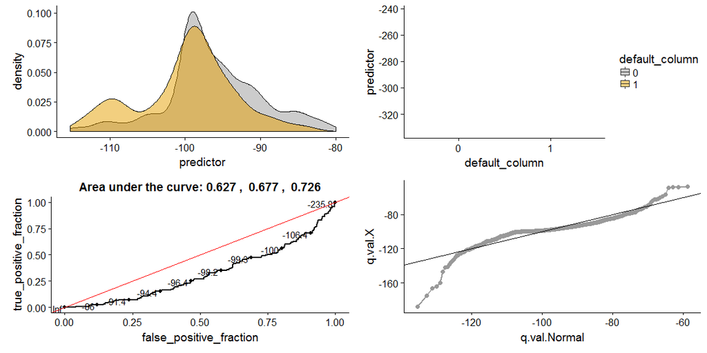

```r
#definisem funkciju za plotovanje
ploting(lrge.training,29,7)
```

- Radna hipoteza-ne znam koji mu je djavo ali evo ovde cemo medijana zdravog je -97.0366946 a nesolventnog je -99.6571025 sto odgovara radnoj hipotezi
- Diskriminativnost - znacajno na 95% znacajnosti, mua
- autlajeri - naravno ima ih
- normalnost - jedan od blizih…

#### Basic Earnings Power Ratio

```
Ignoring unknown parameters: positionRemoved 126 rows containing non-finite values (stat_density).D not labeled 0/1, assuming 1 = 0 and 2 = 1!
```

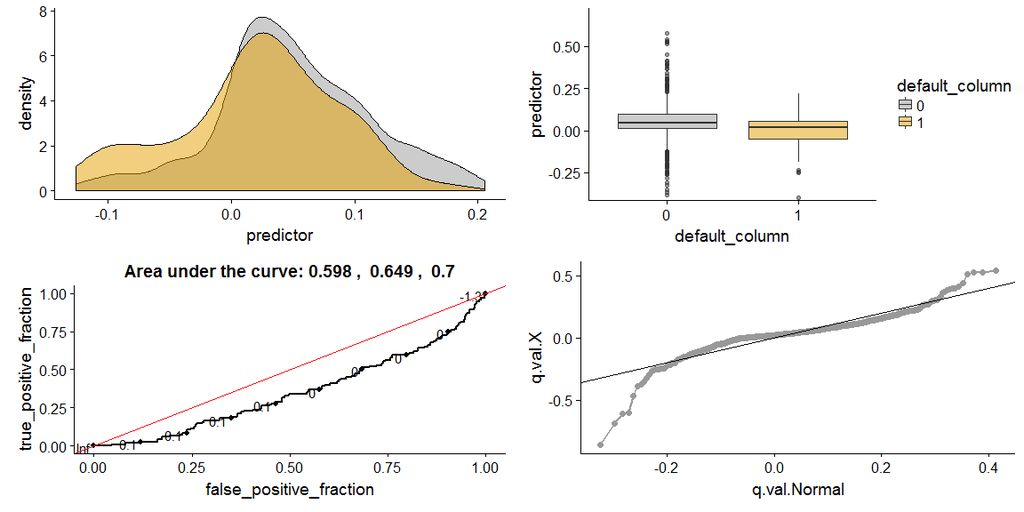

```r
#definisem funkciju za plotovanje
ploting(lrge.training,30,7)
```

- Radna hipoteza-zadovoljena je, veci difolt sa manjom vrednoscu
- Diskriminativnost - ima na 95% znacajnosti, mua
- autlajeri - naravno ima ih
- normalnost - jook…

#### Rast prihoda od prodaje

```
Ignoring unknown parameters: positionRemoved 112 rows containing non-finite values (stat_density).D not labeled 0/1, assuming 1 = 0 and 2 = 1!
```

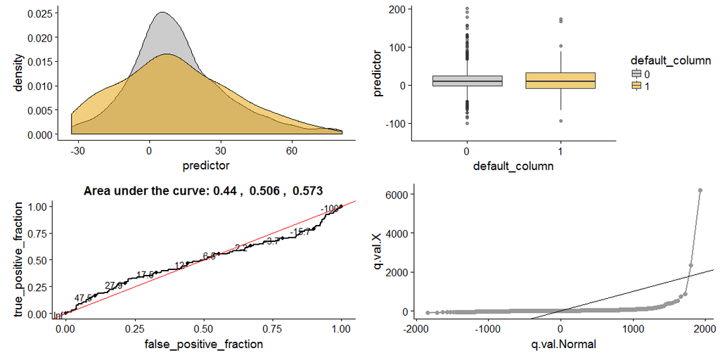

```r
#definisem funkciju za plotovanje
ploting(lrge.training,31,7)
```

- Radna hipoteza-nezadovoljena je, nema vidljive razlike
- Diskriminativnost - nije znacajna na 95% znacajnosti, kandidat za kategoricku
- autlajeri - naravno ima ih
- normalnost - jook…

#### Pokriće neto kamata

```
Ignoring unknown parameters: positionRemoved 124 rows containing non-finite values (stat_density).D not labeled 0/1, assuming 1 = 0 and 2 = 1!
```

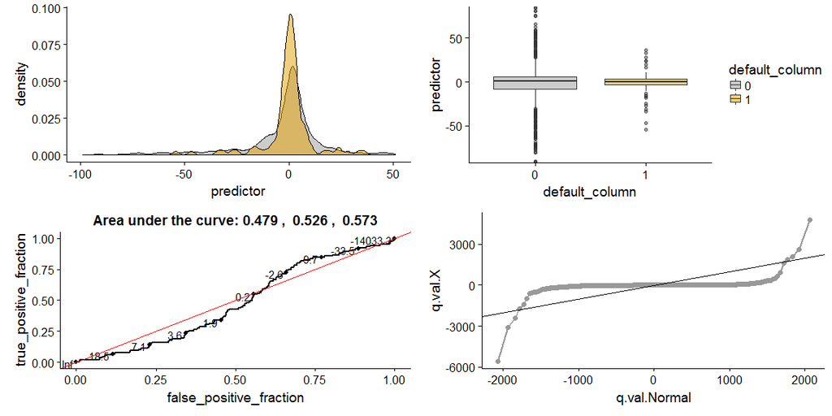

```r
#definisem funkciju za plotovanje
ploting(lrge.training,32,7)
```

- Radna hipoteza-zadovoljena je mada nema vidljive razlike zbog autlajera
- Diskriminativnost - nije znacajna na 95% znacajnosti, medjutim ROC ima s oblik sto znaci da postoji diskriminativnost obrnutog smera na vecim i manjim vrednostima, medjutim ovo znaci i da odnos sa verovatnocom default-a nije monoton, kandidat za kategoricku
- autlajeri - naravno ima ih
- normalnost - jook…

#### Cena tuđih izvora sredstava

```
Ignoring unknown parameters: positionRemoved 126 rows containing non-finite values (stat_density).D not labeled 0/1, assuming 1 = 0 and 2 = 1!
```

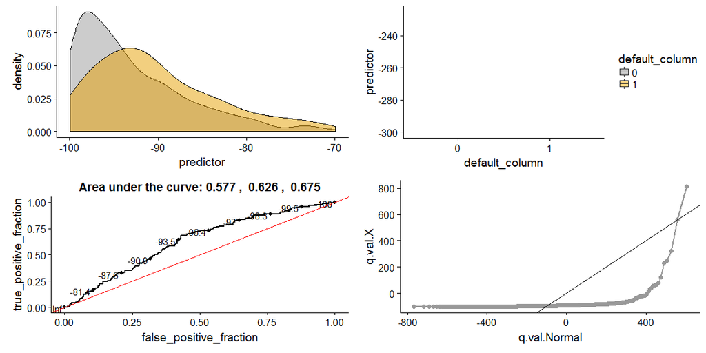

```r
#definisem funkciju za plotovanje
ploting(lrge.training,33,7)
```

#### T1

```
Ignoring unknown parameters: positionRemoved 126 rows containing non-finite values (stat_density).D not labeled 0/1, assuming 1 = 0 and 2 = 1!
```

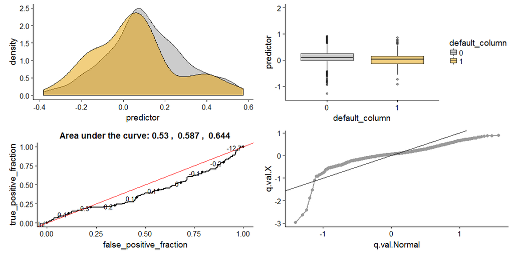

```r
#definisem funkciju za plotovanje
ploting(lrge.training,34,7)
```

- Radna hipoteza-zadovoljena je
- Diskriminativnost - znacajna na 95% znacajnosti, medjutim brine monotonost, moze da prodje
- autlajeri - naravno ima ih
- normalnost - jook…

#### T2

```
Ignoring unknown parameters: positionRemoved 63 rows containing non-finite values (stat_density).D not labeled 0/1, assuming 1 = 0 and 2 = 1!
```

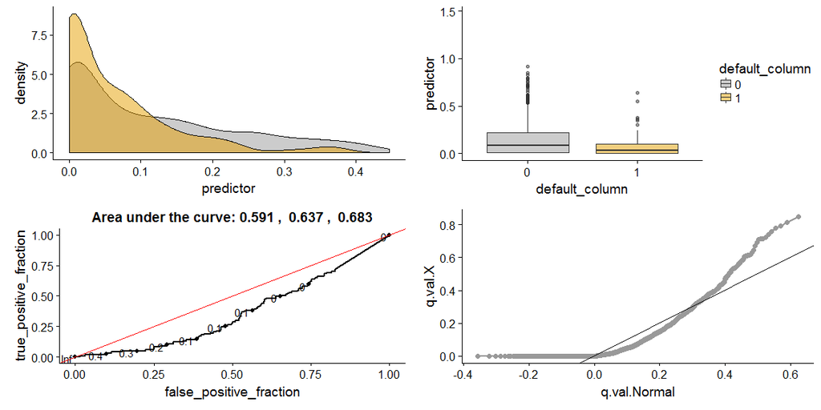

```r
#definisem funkciju za plotovanje
ploting(lrge.training,35,7)
```

- Radna hipoteza-zadovoljena je
- Diskriminativnost - znacajna na 95% znacajnosti
- autlajeri - naravno ima ih
- normalnost - jook…

#### T3

```
Ignoring unknown parameters: positionRemoved 126 rows containing non-finite values (stat_density).D not labeled 0/1, assuming 1 = 0 and 2 = 1!
```

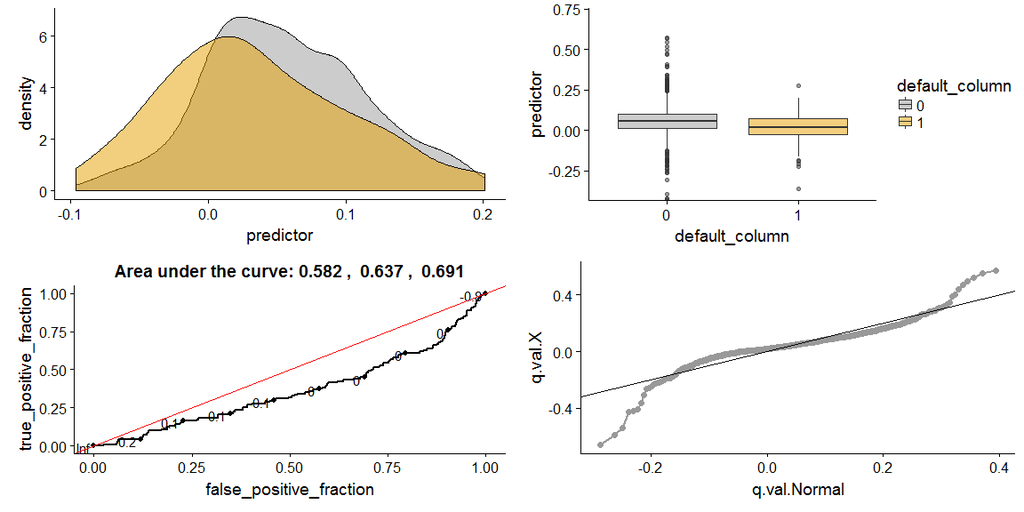

```r
#definisem funkciju za plotovanje
ploting(lrge.training,36,7)
```

- Radna hipoteza-zadovoljena je
- Diskriminativnost - znacajna na 95% znacajnosti
- autlajeri - naravno ima ih
- normalnost - jook…

#### T4

```
Ignoring unknown parameters: positionRemoved 126 rows containing non-finite values (stat_density).D not labeled 0/1, assuming 1 = 0 and 2 = 1!
```

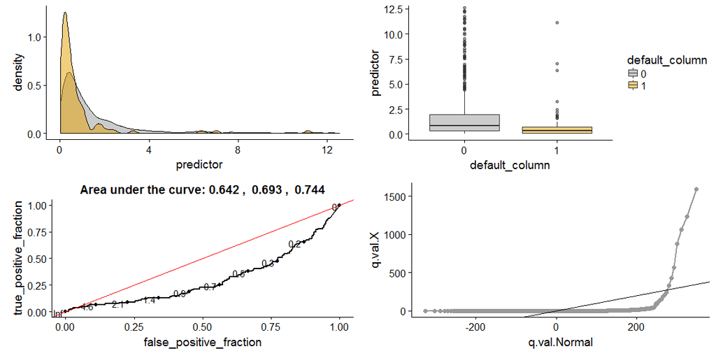

```r
#definisem funkciju za plotovanje
ploting(lrge.training,37,7)
```

- Radna hipoteza-zadovoljena je
- Diskriminativnost - masterpiece
- autlajeri - naravno ima ih
- normalnost - jook…

#### T5

```
Ignoring unknown parameters: positionRemoved 126 rows containing non-finite values (stat_density).D not labeled 0/1, assuming 1 = 0 and 2 = 1!
```

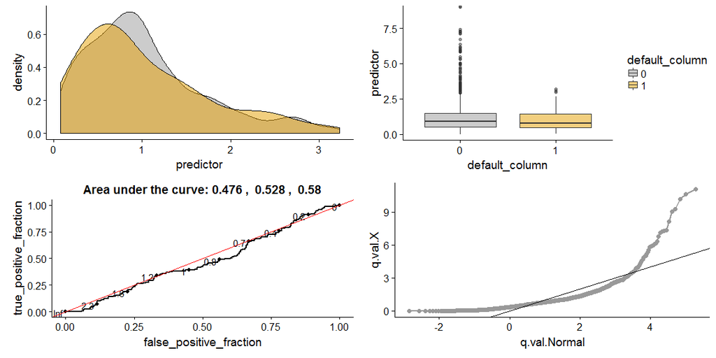

```r
#definisem funkciju za plotovanje
ploting(lrge.training,38,7)
```

- Radna hipoteza-zadovoljena je
- Diskriminativnost - nema
- autlajeri - naravno ima ih
- normalnost - jook…

#### T21

```
Ignoring unknown parameters: positionRemoved 126 rows containing non-finite values (stat_density).D not labeled 0/1, assuming 1 = 0 and 2 = 1!
```

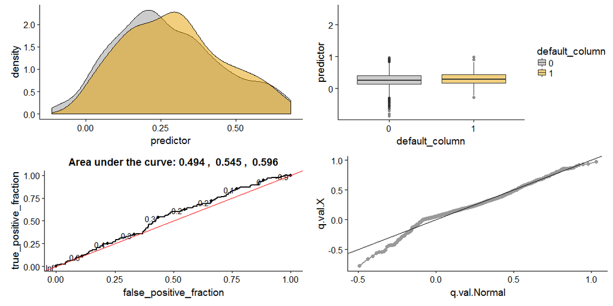

```r
#definisem funkciju za plotovanje
ploting(lrge.training,39,7)
```

- Radna hipoteza-nezadovoljena
- Diskriminativnost - nema, za malo
- autlajeri - naravno ima ih
- normalnost - jook…

#### Altman Z-score 1

```
Ignoring unknown parameters: positionRemoved 126 rows containing non-finite values (stat_density).D not labeled 0/1, assuming 1 = 0 and 2 = 1!
```

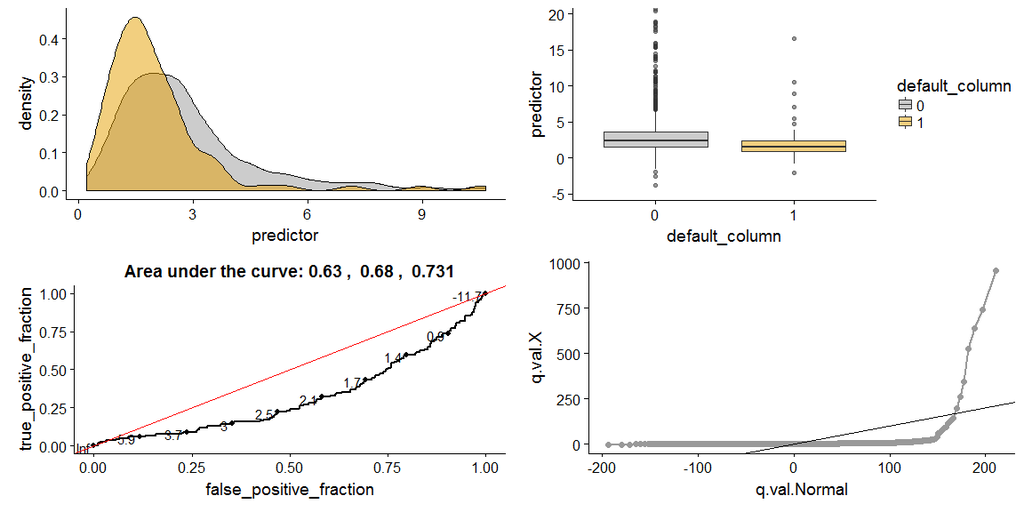

```r
#definisem funkciju za plotovanje
ploting(lrge.training,40,7)
```

- Radna hipoteza-zadovoljena je
- Diskriminativnost - masterpiece
- autlajeri - naravno ima ih
- normalnost - jook…